# Author: Shantanu Tyagi

# Date: 30-01-2021

# ID: 201801015

```python
import pandas as pd
from matplotlib import pyplot as plt
import numpy as np
from scipy import stats
# Reading CSV
df = pd.read_csv('Temperature_2020.csv')
# Station Name
name = 'MOUNT LOFTY AS'
# Filtering
df = df.loc[df['STATION_NAME'] == name]
# Removing large values
df = df[df['TMAX']!=-9999]
df = df[df['TMIN']!=-9999]
print('STATION: ' + name)
# New dataframes for individual analysis
df1 = df['TMAX']
df2 = df['TMIN']
```

```
STATION: MOUNT LOFTY AS
```

#### In the above code, I have first imported the CSV file in a dataframe and selected all columns from the rows having the desired station name. Then, the large values like -9999 are filtered off and finally we get two dataframes for this station, one for TMAX and other for TMAX.

```python
# Histogram function (data array, number of bins, subplot number, normalised?, cumulative?)
def plotHistogram(data, bins, i, norm, cumu):
    # Sub plot
    plt.subplot(1, 2, i)
    # assign weights if normalisation has to take place
    if norm:
        size = len(data)
    else: # else weights = 1
        size = 1
    # Hist function gives heights, bin intervals and patches with weight array to normalise heights
    n, bins, patches = plt.hist(data, bins=bins, facecolor='#2ab0ff', edgecolor='#e0e0e0', linewidth=0.5, alpha=0.8, cumulative=cumu, weights = np.ones_like(data)*1./size)
    nn = max(n)
    # patches are used to change color of the bars in histogram
    for i in range(len(patches)):
        patches[i].set_facecolor(plt.cm.viridis((n[i]/nn)))
    # plotting starts here
    plt.title(data.name + ' Data Histogram, bins: '+str(i+1), fontsize=20)
    plt.xlabel('Temperature', fontsize=16)
    if norm:
        plt.ylabel('Normalised Frequency', fontsize=16)
    else:
        plt.ylabel('Frequency', fontsize=16)
    plt.grid(axis='y', alpha=0.75)
```

#### In the above code, I have defined a function that plots histogram based on the parameters that are given to the function. It takes the data array, the number of bins we want in the histogram, the sub plot number since 2 plots are to be plotted side by side and lastly if we want the simple histogram or a normalised histogram such that sum of heights of individual bars equals to 1.

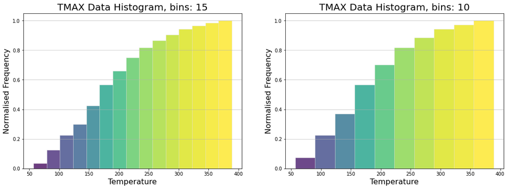

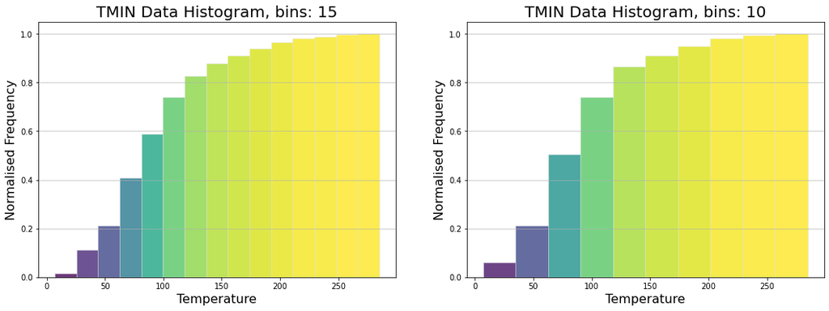

```python
# plot histograms  by calling the function
plt.figure(figsize=(18, 6))
# TMAX histogram
plotHistogram(df1,15, 1, True, True) # 15 bins
plotHistogram(df1,10, 2, True, True) # 10 bins
plt.show()
plt.figure(figsize=(18, 6))
# TMIN histogram
plotHistogram(df2,15, 1, True, True) # 15 bins
plotHistogram(df2,10, 2, True, True) # 10 bins
plt.show()
```

#### 4 normalised and cumulative distribution histograms have been plotted, 2 each for TMAX and TMIN respectively with two values of bin size, i.e. 15 and 10 respectively.

### The Pearson correlation coefficient measures the linear association between variables. Its value can be interpreted like so:

#### +1 - Complete positive correlation

#### +0.8 - Strong positive correlation

#### +0.6 - Moderate positive correlation

#### 0 - no correlation whatsoever

#### -0.6 - Moderate negative correlation

#### -0.8 - Strong negative correlation

#### -1 - Complete negative correlation

```python
slope, intercept, r_value, p_value, std_err = stats.linregress(df1, df2)
x = np.linspace(min(df1),max(df1),1000)
y = slope*x + intercept
```

```python
print('r   : ' + str(r_value))
print('r^2 : ' + str(r_value*r_value))
```

```
r   : 0.7745365160843741
r^2 : 0.5999068147481199
```

### Above we have the r and r^2 values printed. represents the proportion of the variance for a dependent variable that's explained by an independent variable or variables in a regression model. It is called R-squared because in a simple regression model it is just the square of the correlation between the dependent and independent variables, which is commonly denoted by “r”. R-squared explains to what extent the variance of one variable explains the variance of the second variable. So, if the R2 of a model is 0.50, then approximately half of the observed variation can be explained by the model's inputs. R-squared evaluates the scatter of the data points around the fitted regression line. It is also called the coefficient of determination, or the coefficient of multiple determination for multiple regression. For the same data set, higher R-squared values represent smaller differences between the observed data and the fitted values. However this does not mean that a good R-squared value is desired, it depends on the context actually. For example, studies that try to explain human behavior generally have R2 values less than 50%. People are just harder to predict than things like physical processes. Fortunately, if you have a low R-squared value but the independent variables are statistically significant, you can still draw important conclusions about the relationships between the variables. Thus a high r-squared value is necessary but not always sufficient.

[figure not shown]

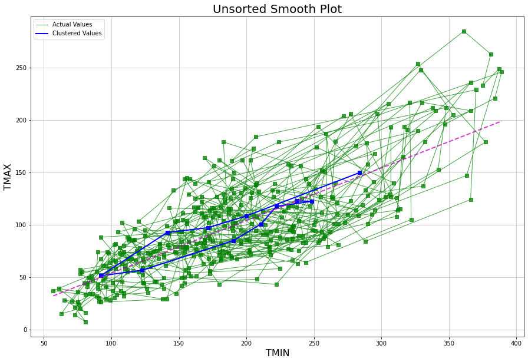

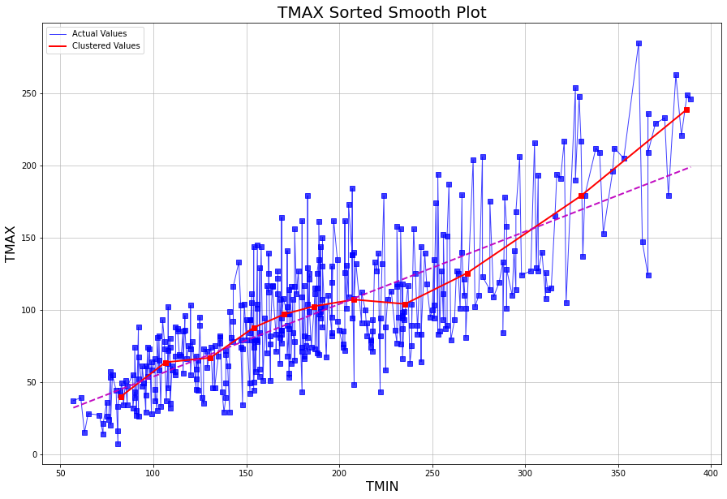

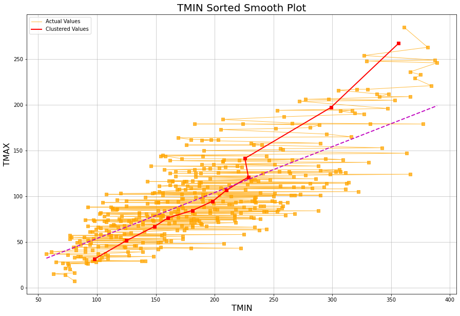

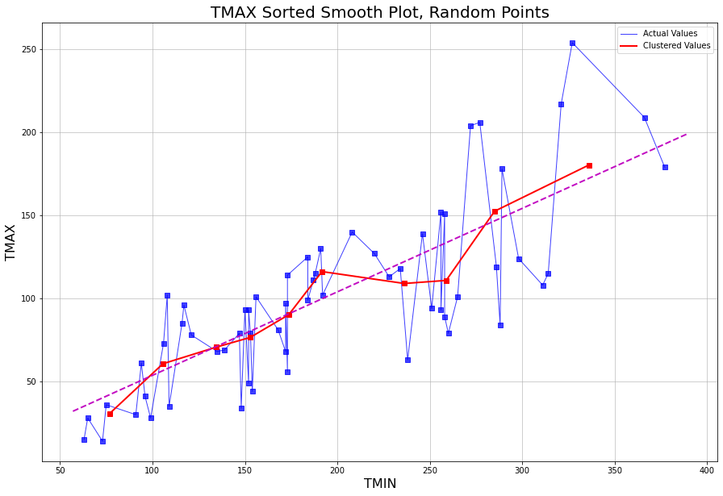

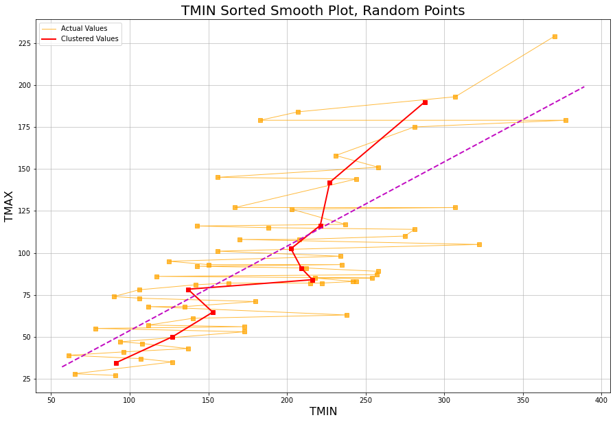

```python
plt.figure(figsize=(15, 10))
plt.scatter(df1, df2, c=df1+df2, cmap="jet", s=75, alpha=0.8, edgecolor='#000000', linewidth = 0.5)
plt.plot(x,y, 'b--', alpha=0.75, linewidth = 2)
plt.title('Scattered Plot', fontsize=20)
plt.xlabel('TMIN', fontsize=16)
plt.ylabel('TMAX', fontsize=16)
plt.grid(alpha=0.75)
plt.show()

plt.figure(figsize=(15, 10))
plt.plot(df1,df2,linewidth = 1, color='green', alpha=0.75)
plt.plot(df1,df2,'s',linewidth = 0.5, color='green', alpha=0.75, label='_nolegend_')
dfs11 = df1.groupby(np.arange(len(df1))//41).mean()
dfs22 = df2.groupby(np.arange(len(df2))//41).mean()
plt.plot(dfs11, dfs22, linewidth = 2, color='blue')
plt.plot(dfs11, dfs22, 's', linewidth = 1, color='blue')
plt.plot(x,y, 'm--', alpha=0.75, linewidth = 2)
plt.title('Unsorted Smooth Plot', fontsize=20)
plt.xlabel('TMIN', fontsize=16)
plt.ylabel('TMAX', fontsize=16)
plt.legend(['Actual Values','Clustered Values'])
plt.grid(alpha=0.75)
plt.show()

plt.figure(figsize=(15, 10))
dfs = df.sort_values(by=['TMAX'])
dfs1 = dfs.groupby(np.arange(len(dfs))//41).mean()
df11 = dfs1['TMAX']
df22 = dfs1['TMIN']
plt.plot(dfs['TMAX'],dfs['TMIN'],linewidth = 1, color='blue', alpha=0.75)
plt.plot(dfs['TMAX'],dfs['TMIN'],'s',linewidth = 0.5, color='blue', alpha=0.75, label='_nolegend_')
plt.plot(df11,df22, linewidth = 2, color='red')
plt.plot(df11,df22, 's', linewidth = 1, color='red')
plt.plot(x,y, 'm--', alpha=0.95, linewidth = 2)
plt.title('TMAX Sorted Smooth Plot', fontsize=20)
plt.xlabel('TMIN', fontsize=16)
plt.ylabel('TMAX', fontsize=16)
plt.legend(['Actual Values','Clustered Values'])
plt.grid(alpha=0.75)
plt.show()

plt.figure(figsize=(15, 10))
dfs = df.sort_values(by=['TMIN'])
dfs1 = dfs.groupby(np.arange(len(dfs))//41).mean()
df11 = dfs1['TMAX']
df22 = dfs1['TMIN']
plt.plot(dfs['TMAX'],dfs['TMIN'],linewidth = 1, color='orange', alpha=0.75)
plt.plot(dfs['TMAX'],dfs['TMIN'],'s',linewidth = 0.5, color='orange', alpha=0.75, label='_nolegend_')
plt.plot(df11,df22, linewidth = 2, color='red')
plt.plot(df11,df22, 's', linewidth = 1, color='red')
plt.plot(x,y, 'm--', alpha=0.95, linewidth = 2)
plt.title('TMIN Sorted Smooth Plot', fontsize=20)
plt.xlabel('TMIN', fontsize=16)
plt.ylabel('TMAX', fontsize=16)
plt.legend(['Actual Values','Clustered Values'])
plt.grid(alpha=0.75)
plt.show()

#random points, say 41 points
plt.figure(figsize=(15, 10))
dfs = df.sample(n = 60)
dfs = dfs.sort_values(by=['TMAX'])
dfs1 = dfs.groupby(np.arange(len(dfs))//6).mean()
df11 = dfs1['TMAX']
df22 = dfs1['TMIN']
plt.plot(dfs['TMAX'],dfs['TMIN'],linewidth = 1, color='blue', alpha=0.75)
plt.plot(dfs['TMAX'],dfs['TMIN'],'s',linewidth = 0.5, color='blue', alpha=0.75, label='_nolegend_')
plt.plot(df11,df22, linewidth = 2, color='red')
plt.plot(df11,df22, 's', linewidth = 1, color='red')
plt.plot(x,y, 'm--', alpha=0.95, linewidth = 2)
plt.title('TMAX Sorted Smooth Plot, Random Points', fontsize=20)
plt.xlabel('TMIN', fontsize=16)
plt.ylabel('TMAX', fontsize=16)
plt.legend(['Actual Values','Clustered Values'])
plt.grid(alpha=0.75)
plt.show()

plt.figure(figsize=(15, 10))
dfs = df.sample(n = 60)
dfs = dfs.sort_values(by=['TMIN'])
dfs1 = dfs.groupby(np.arange(len(dfs))//6).mean()
df11 = dfs1['TMAX']
df22 = dfs1['TMIN']
plt.plot(dfs['TMAX'],dfs['TMIN'],linewidth = 1, color='orange', alpha=0.75)
plt.plot(dfs['TMAX'],dfs['TMIN'],'s',linewidth = 0.5, color='orange', alpha=0.75, label='_nolegend_')
plt.plot(df11,df22, linewidth = 2, color='red')
plt.plot(df11,df22, 's', linewidth = 1, color='red')
plt.plot(x,y, 'm--', alpha=0.95, linewidth = 2)
plt.title('TMIN Sorted Smooth Plot, Random Points', fontsize=20)
plt.xlabel('TMIN', fontsize=16)
plt.ylabel('TMAX', fontsize=16)
plt.legend(['Actual Values','Clustered Values'])
plt.grid(alpha=0.75)
plt.show()
```